# FunCN (Functional Cellular Neighborhood) tutorial

# Introduction

**Why we developed FunCN?**  
We developed **FunCN** to overcome the limitations of conventional neighborhood analysis methods such as KNN approach. The traditional methods rely on fixed boundaries, assigning equal weights to all neighboring cells within a cutoff distance, which can obscure the nuanced influence of spatial proximity. In reality, cellular interactions are distance-dependent, where closer cells exert stronger biological effects than those farther away. To address this, **FunCN** quantifies cellular influence through a continuous, distance-weighted representation that captures the gradual decay of interaction strength across spatial scales.

**RESOURCES** Cho, Y., Lee, J.W., Shin, S.M., Hernandez, A.G., Yuan, X., Schneider, J., Hooper, J.E., Wood, L.D., Jaffee, E.M., Deshpande, A. and Ho, W.J., 2025. Modeling cellular influence delineates functionally relevant cellular neighborhoods in primary and metastatic pancreatic ductal adenocarcinoma. bioRxiv, pp.2025-06. doi: https://doi.org/10.1101/2025.06.12.659314

# Apply FunCN function

**Description**  
Computes smoothed, leave-one-out kernel weights for each point, grouped by cell-type marks.

**Requirements** Input `expr` must contain:

- `x_col`: x-coordinates
- `y_col`: y-coordinates
- `celltype_col`: cell type (mark)

**Multi-sample data**  
If there is multi-sample data in one data frame:

- Set `multisample = TRUE`
- Add `sample_col = "sample_col_name"`

**Smoothing kernels**

- A character string specifying the kernel
- spatstat smooth function Options: `"gaussian"`, `"epanechnikov"`, `"quartic"`, `"disc"`

# Load data

```r
library(ggplot2)
library(dplyr)
library(tibble)
library(cowplot)
library(FNN)
library(tidyr)
```

```r
radial_pts <- readRDS('../data/radial_pts.rds')
equidist_pts <- readRDS('../data/equidist_pts.rds')
```

```r
source('./functions/compute_FunCN.R')

# check data format
print(radial_pts)
```

```
## # A tibble: 13 × 4
##    label     x     y r_from_A
##    <chr> <dbl> <dbl>    <dbl>
##  1 A     25    25           0
##  2 B     29    25           4
##  3 B     25    30           5
##  4 B     19    25           6
##  5 B     25    17           8
##  6 C     33.7  30          10
##  7 C     19    35.4        12
##  8 C     12.9  18          14
##  9 C     33    11.1        16
## 10 D     34    40.6        18
## 11 D      7.68 35          20
## 12 D     14.0   5.95       22
## 13 D     45.8  13.0        24
```

```r
radial_pts <- as.data.frame(radial_pts) # transform to data.frame class
equidist_pts <- as.data.frame(equidist_pts)
```

# Usage

```r
equi_spatwt <- compute_FunCN(expr = equidist_pts,
                             x_col = "x",
                             y_col = "y",
                             celltype_col = "label",
                             multisample = FALSE,
                             sample_col = NA,
                             kernels = "gaussian",
                             sigma = 10)

radi_spatwt <- compute_FunCN(expr = radial_pts,
                             x_col = "x",
                             y_col = "y",
                             celltype_col = "label",
                             multisample = FALSE,
                             sample_col = NA,
                             kernels = "gaussian",
                             sigma = 10)

print(equi_spatwt)
```

```
##               A         B         C         D
## 1:A  0.00000000 0.3333333 0.3333333 0.3333333
## 2:B  0.13065578 0.1856269 0.3463997 0.3373177
## 3:B  0.14052162 0.1766087 0.3331790 0.3496907
## 4:B  0.09905516 0.1652314 0.4046282 0.3310852
## 5:B  0.08337780 0.1688851 0.3853733 0.3623638
## 6:C  0.13454467 0.3304859 0.1911520 0.3438175
## 7:C  0.13900895 0.3403571 0.1747076 0.3459264
## 8:C  0.08858441 0.3978904 0.1477654 0.3657598
## 9:C  0.08399022 0.3808588 0.1701255 0.3650254
## 10:D 0.14036634 0.3328108 0.3358539 0.1909690
## 11:D 0.13622189 0.3449146 0.3335331 0.1853305
## 12:D 0.08519574 0.3937758 0.3826696 0.1383588
## 13:D 0.09363642 0.3296969 0.4246001 0.1520666
```

```r
print(radi_spatwt)
```

```
##               A         B         C          D
## 1:A  0.00000000 0.6021209 0.3123472 0.08553188
## 2:B  0.17674990 0.4004610 0.3277815 0.09500763
## 3:B  0.16762787 0.3763478 0.3353828 0.12064151
## 4:B  0.16588770 0.3873138 0.3329832 0.11381527
## 5:B  0.16285350 0.3826963 0.3449207 0.10952952
## 6:C  0.15457487 0.5289471 0.1325232 0.18395481
## 7:C  0.13443136 0.5005388 0.1374700 0.22755980
## 8:C  0.12551848 0.5259685 0.1147688 0.23374415
## 9:C  0.11605835 0.5140938 0.1222330 0.24761488
## 10:D 0.10459919 0.4123894 0.4628065 0.02020492
## 11:D 0.08662284 0.3988396 0.4896524 0.02488521
## 12:D 0.06982326 0.4109171 0.5056271 0.01363248
## 13:D 0.06294896 0.2984251 0.6205008 0.01812515
```

# Compare the FunCN score with KNN

```r
get_neighbor_props <- function(df, k = 10, label_col = "label", xy_cols = c("x","y"), all_labels = NULL) {
  # run kNN
  knn_idx <- get.knn(df[, xy_cols], k = k)$nn.index
  # pull labels as vector
  labels_vec <- df[[label_col]]
  # map neighbor indices -> labels
  knn_labels <- matrix(labels_vec[knn_idx],
                       nrow = nrow(knn_idx),
                       ncol = ncol(knn_idx))

  # count label frequency per row
  freq_mat <- t(apply(knn_labels, 1, function(neigh_labels) {
    tab <- table(factor(neigh_labels, levels = all_labels))
    as.numeric(tab)
  }))
  colnames(freq_mat) <- all_labels

  # convert to proportions
  prop_mat <- as.data.frame(freq_mat/k)
  # set rownames: "<rownames>:<label>"
  rownames(prop_mat) <- paste0(rownames(df), ":", df[[label_col]])
  return(prop_mat)
}

# define labels
all_labels <- unique(c(equidist_pts$label, radial_pts$label))

# run for each dataset
prop_df_equi <- get_neighbor_props(equidist_pts, k = 10, all_labels = all_labels)
prop_df_radi <- get_neighbor_props(radial_pts,k = 10, all_labels = all_labels)

print(prop_df_equi)
```

```
##        A   B   C   D
## 1:A  0.0 0.4 0.2 0.4
## 2:B  0.1 0.2 0.3 0.4
## 3:B  0.1 0.2 0.3 0.4
## 4:B  0.1 0.3 0.3 0.3
## 5:B  0.1 0.1 0.4 0.4
## 6:C  0.1 0.3 0.2 0.4
## 7:C  0.1 0.4 0.2 0.3
## 8:C  0.1 0.4 0.2 0.3
## 9:C  0.1 0.3 0.2 0.4
## 10:D 0.1 0.3 0.4 0.2
## 11:D 0.1 0.4 0.3 0.2
## 12:D 0.1 0.4 0.4 0.1
## 13:D 0.1 0.3 0.3 0.3
```

```r
print(prop_df_radi)
```

```
##        A   B   C   D
## 1:A  0.0 0.4 0.4 0.2
## 2:B  0.1 0.3 0.4 0.2
## 3:B  0.1 0.3 0.4 0.2
## 4:B  0.1 0.3 0.4 0.2
## 5:B  0.1 0.3 0.4 0.2
## 6:C  0.1 0.4 0.3 0.2
## 7:C  0.1 0.4 0.3 0.2
## 8:C  0.1 0.4 0.3 0.2
## 9:C  0.1 0.4 0.3 0.2
## 10:D 0.1 0.4 0.3 0.2
## 11:D 0.1 0.4 0.3 0.2
## 12:D 0.1 0.4 0.4 0.1
## 13:D 0.1 0.4 0.3 0.2
```

# Compare spatial organization with cellular influence score

### Case 1: Equidistance example

```r
p1 <- ggplot() +
  geom_segment(data = equidist_pts %>% dplyr::filter(label != "A"),
               aes(x = cx, y = cy, xend = x, yend = y, color = label),
               linewidth = 0.7, alpha = 0.7) +
  geom_point(data = equidist_pts, aes(x, y, color = label, shape = label), size = 3.5) +
  geom_point(
    data = radial_pts %>% dplyr::filter(label == "A"),
    aes(x, y, color = label, shape = label),
    size = 5, show.legend = FALSE
  ) +
  coord_fixed(xlim = c(0, 50), ylim = c(0, 50)) +
  labs(title = "(i) Equal distance", x = NULL, y = NULL) +
  theme_minimal() +
  theme(legend.title = element_blank(),
        plot.title = element_text(hjust = 0.5))+
  scale_shape_manual(
    values = c("A" = 18,"B" = 17, "C" = 15, "D" = 16))
```

### Case 2: Radial-distance example

```r
# Parameters
cx <- 25; cy <- 25
r_B <- 9
r_C <- 17
r_D <- 25

# circles for B, C, D
circle_df <- function(cx, cy, r, n = 360) {
  th <- seq(0, 2*pi, length.out = n)
  tibble(x = cx + r*cos(th), y = cy + r*sin(th))
}

circles <- bind_rows(
  circle_df(cx, cy, r_B) %>% mutate(label = "B"),
  circle_df(cx, cy, r_C) %>% mutate(label = "C"),
  circle_df(cx, cy, r_D) %>% mutate(label = "D")
)

color_map <- c(B = "#1b9e77", C = "#d95f02", D = "#7570b3")

# plot
p2 <- ggplot() +
 geom_path(data = circles, aes(x, y, color = label), linewidth = 0.8, linetype = 2) +
  geom_segment(data = radial_pts %>% dplyr::filter(label != "A"),
               aes(x = cx, y = cy, xend = x, yend = y, color = label),
               linewidth = 0.7, alpha = 0.7) +
  geom_point(data = radial_pts, aes(x, y, color = label, shape = label), size = 3.5) +
  # draw A on top
  geom_point(
    data = radial_pts %>% dplyr::filter(label == "A"),
    aes(x, y, color = label, shape = label),
    size = 5, show.legend = FALSE
  ) +
  coord_fixed(xlim = c(0, 50), ylim = c(0, 50)) +
  labs(title = "(ii) Radial distance", x = NULL, y = NULL) +
  theme_minimal() +
  theme(legend.title = element_blank(),
        plot.title = element_text(hjust = 0.5))+
  scale_shape_manual(
    values = c("A" = 18,"B" = 17, "C" = 15, "D" = 16))
```

### Compile data for cellular influence score

```r
# extract scores for A (reference)
to_long <- function(df, method_name, sample_name) {
  df %>%
    as.data.frame() %>%
    pivot_longer(
      cols = c("A","B","C","D"),
      names_to = "label",
      values_to = "value"
    ) %>%
    mutate(
      method = method_name,
      sample = sample_name
    )
}

long_equi_fun <- to_long(equi_spatwt[1, ], method_name = "FunCN", sample_name = "equidist")
long_radi_fun <- to_long(radi_spatwt[1, ], method_name = "FunCN", sample_name = "radial")
long_equi_knn <- to_long(prop_df_equi[1, ], method_name = "KNN", sample_name = "equidist")
long_radi_knn <- to_long(prop_df_radi[1, ], method_name = "KNN", sample_name = "radial")

data_for_plot <- as.data.frame(rbind(long_equi_fun, long_radi_fun, long_equi_knn, long_radi_knn))

p3 <- ggplot(data_for_plot[data_for_plot$sample=="equidist", ],
             aes(x=label, y=value, fill=method))+
  geom_bar(stat = "identity", position = position_dodge(width = 0.9)) +
  geom_text(
    aes(label = round(value, 3)),
    position = position_dodge(width = 0.9),
    vjust = -0.3,
    size = 3
  ) +
  theme_minimal() +
  scale_y_continuous(expand = expansion(mult = c(0, 0.1)))+
  labs(x = NULL, y = "Scores", title = NULL)

p4<- ggplot(data_for_plot[data_for_plot$sample=="radial", ],
             aes(x=label, y=value, fill=method))+
  geom_bar(stat = "identity", position = position_dodge(width = 0.9)) +
  geom_text(
    aes(label = round(value, 3)),
    position = position_dodge(width = 0.9),
    vjust = -0.3,
    size = 3
  ) +
  theme_minimal() +
  scale_y_continuous(expand = expansion(mult = c(0, 0.1)))+
  labs(x = NULL, y = "Scores", title = NULL)
```

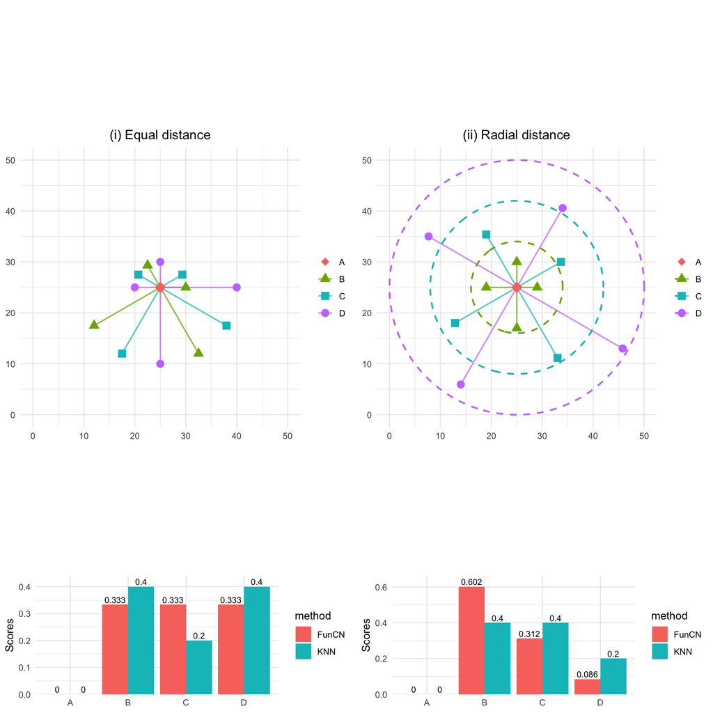

```r
plot_grid(p1, p2, p3, p4, ncol = 2, rel_heights = c(4, 1))
```